# Misleading Claims and What Stays Human: Penguins, Wine, and the Himalaya

2026-11-16

# How to use these notes

This file has the full code for today’s live coding, posted before class. It follows the slides in order.

The code is split into sections. Each section starts with a **CHECKPOINT** chunk. A checkpoint chunk rebuilds everything the section needs from scratch: it loads the packages, loads the data, and redoes the earlier steps. If you hit an error or fall behind, run the most recent checkpoint chunk and you are caught up. You do not need to fix the earlier error first.

The plots are interactive (`plotly`): hover to read the details, and click an entry in a legend to hide or show that group. If you have not installed the package, run this once in the console:

```r
install.packages("plotly")
```

Today has two parts. **Part 1:** how do data and models produce misleading claims even when nobody is trying to mislead anyone? **Part 2:** AI can write the analysis, so what is left for a human to do?

# Part 1: How misleading claims get produced

# Section 1: Mechanism 1, a model trained on one slice of the world

```r
# CHECKPOINT 1 ------------------------------------------------------------
require(tidyverse)
require(plotly)

gms <- read_rds("https://github.com/jbisbee1/DS1000_F2026/raw/main/data/game_summary.Rds")
pg <- read_rds("https://github.com/jbisbee1/DS1000_F2026/raw/refs/heads/main/data/penguins.rds") %>%
  drop_na() %>%
  mutate(male = sex == "male")
```

Recall the win-predictor from the classification unit. This time we train it **only on home games**, then check how it does on home games and on away games.

```r
train_home <- gms %>% filter(locationGame == "H")
test_away <- gms %>% filter(locationGame == "A")

model_home_only <- lm(isWin ~ tov + pts + treb + pctFG, data = train_home)

acc_on <- function(model, newdata) {
  preds <- predict(model, newdata = newdata)
  mean((preds >= 0.5) == newdata$isWin, na.rm = TRUE)
}

c(home = acc_on(model_home_only, train_home),
  away = acc_on(model_home_only, test_away))
```

```
##      home      away
## 0.7482385 0.7371274
```

Now a second example with new data. Each row of `pg` is one penguin measured at a research station in Antarctica. Suppose a researcher wants a quick rule that predicts a penguin’s sex from its body mass, and has data only from **Adelie** penguins. They fit the model on half of those and keep the other half for testing.

```r
adelie <- pg %>%
  filter(species == "Adelie")

set.seed(123)
inds <- sample(1:nrow(adelie), size = round(nrow(adelie) / 2), replace = FALSE)

train_adelie <- adelie %>% slice(inds)
test_adelie <- adelie %>% slice(-inds)

m_mass <- lm(male ~ body_mass_g, data = train_adelie)

eval_set <- bind_rows(test_adelie,
                      pg %>% filter(species != "Adelie")) %>%
  mutate(score = predict(m_mass, newdata = .),
         predicted_male = score >= 0.5)

eval_set %>%
  group_by(species) %>%
  summarise(n_penguins = n(),
            share_actually_male = mean(male),
            share_predicted_male = mean(predicted_male),
            accuracy = mean(predicted_male == male))
```

```
## # A tibble: 3 × 5
##   species   n_penguins share_actually_male share_predicted_male accuracy
##   <chr>          <int>               <dbl>                <dbl>    <dbl>
## 1 Adelie            73               0.479                0.438    0.822
## 2 Chinstrap         68               0.5                  0.471    0.794
## 3 Gentoo           119               0.513                1        0.513
```

On held-out Adelie penguins the rule is right most of the time. On Gentoo penguins it is no better than a coin flip: the model predicts “male” for **every** Gentoo penguin, and about half of them are. Hover over the plot to see why.

```r
p_pred <- eval_set %>%
  ggplot(aes(x = body_mass_g, y = score, color = species,
             text = paste0(species, ", actually ", sex, "<br>", body_mass_g, " g",
                           "<br>Score: ", round(score, 2)))) +
  geom_point(alpha = 0.6) +
  geom_hline(yintercept = 0.5, linetype = "dashed") +
  labs(x = "Body mass (g)", y = "Predicted score (0.5 = threshold)", color = "Species")

ggplotly(p_pred, tooltip = "text")
```

[interactive chart not shown]

The model learned that “heavy means male” from Adelie penguins. A heavy Gentoo is just a typical Gentoo. The predictions arrive as clean numbers with no warning. Nobody intended to build a biased rule. The training data were simply a slice of the penguins.

**PAUSE: everyone should be here. If not, run the next checkpoint.**

# Section 2: Mechanism 2, relationships that are coincidental or reverse

```r
# CHECKPOINT 2 ------------------------------------------------------------
require(tidyverse)
require(plotly)
pg <- read_rds("https://github.com/jbisbee1/DS1000_F2026/raw/refs/heads/main/data/penguins.rds") %>%
  drop_na() %>%
  mutate(male = sex == "male")
```

Here are two random sequences, generated independently. They share no cause.

```r
set.seed(42)
spurious_dat <- tibble(
  year = 2001:2020,
  series_a = cumsum(rnorm(20)),
  series_b = cumsum(rnorm(20))
)

cor(spurious_dat$series_a, spurious_dat$series_b)
```

```
## [1] 0.1741446
```

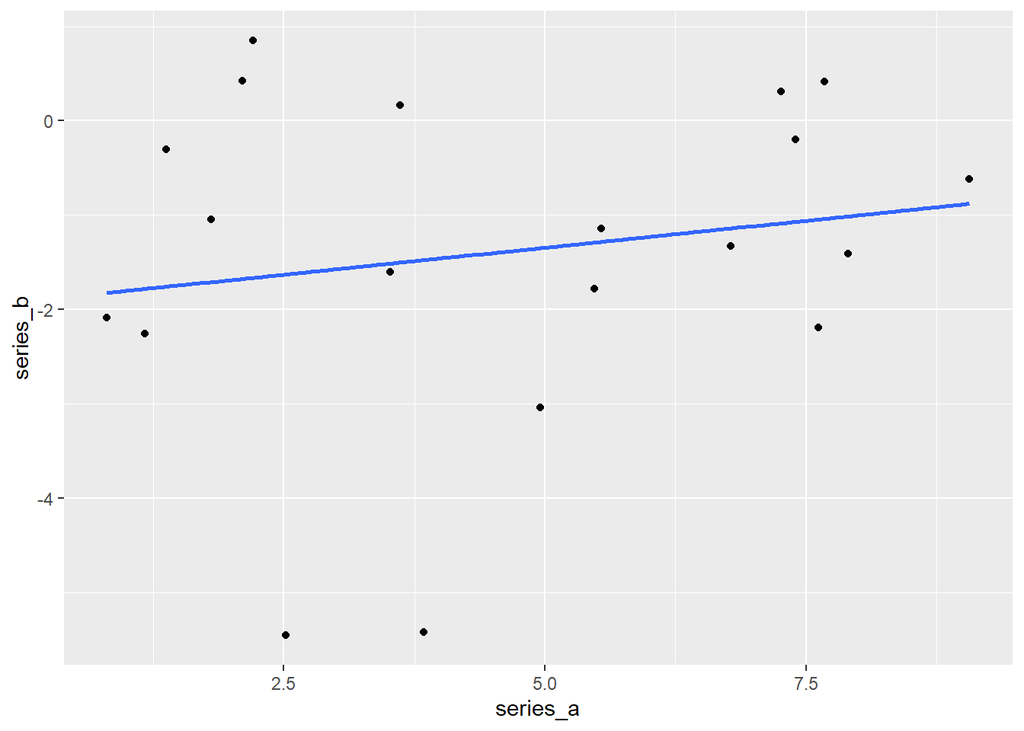

```r
spurious_dat %>%
  ggplot(aes(x = series_a, y = series_b)) +
  geom_point() +
  geom_smooth(method = "lm", se = FALSE)
```

The correlation is not a coding error. With enough random series, some pairs will look related by chance.

A real relationship can also point the wrong way. Do penguins with longer bills have deeper or shallower bills?

```r
cor(pg$bill_length_mm, pg$bill_depth_mm)
```

```
## [1] -0.2286256
```

```r
pg %>%
  group_by(species) %>%
  summarise(n_penguins = n(),
            correlation = cor(bill_length_mm, bill_depth_mm))
```

```
## # A tibble: 3 × 3
##   species   n_penguins correlation
##   <chr>          <int>       <dbl>
## 1 Adelie           146       0.386
## 2 Chinstrap         68       0.654
## 3 Gentoo           119       0.654
```

Pooled, the relationship is **negative**. Within every species it is **positive**. This is Simpson’s paradox, the same pattern as the ice cream and drowning example in Homework 6. The dashed black line is the pooled trend and the colored lines are the trends within each species. Click a species in the legend to hide it.

```r
p_simpson <- pg %>%
  ggplot(aes(x = bill_length_mm, y = bill_depth_mm)) +
  geom_point(aes(color = species,
                 text = paste0(species, ", ", sex, "<br>Length: ", bill_length_mm,
                               " mm<br>Depth: ", bill_depth_mm, " mm")),
             alpha = 0.6) +
  geom_smooth(method = "lm", se = FALSE, color = "black", linetype = "dashed") +
  geom_smooth(aes(color = species), method = "lm", se = FALSE) +
  labs(x = "Bill length (mm)", y = "Bill depth (mm)", color = "Species")

ggplotly(p_simpson, tooltip = "text")
```

[interactive chart not shown]

Someone who reported only the pooled number would be reporting a real number that points the wrong way for every single species. No fabrication is needed.

**PAUSE: everyone should be here. If not, run the next checkpoint.**

# Section 3: Mechanism 3, a number that sounds more precise than it is

```r
# CHECKPOINT 3 ------------------------------------------------------------
require(tidyverse)
require(plotly)
wine <- read_rds("https://github.com/jbisbee1/DS1000_F2026/raw/refs/heads/main/data/wine_reviews.rds")
```

A random sample of 10,000 wine reviews from a professional wine magazine, each with a score from 80 to 100 points. A common headline is a ranking: **which country makes the best wine?** Here is the average score for every country with at least 100 reviews, with a 95% interval. Hover for the numbers.

```r
by_country <- wine %>%
  group_by(country) %>%
  summarise(n_reviews = n(),
            mean_points = mean(points),
            se = sd(points) / sqrt(n()),
            lower = mean_points - 1.96 * se,
            upper = mean_points + 1.96 * se) %>%
  filter(n_reviews >= 100) %>%
  arrange(desc(mean_points)) %>%
  mutate(rank = row_number())

by_country %>%
  select(rank, country, n_reviews, mean_points) %>%
  mutate(mean_points = round(mean_points, 2))
```

```
## # A tibble: 12 × 4
##     rank country      n_reviews mean_points
##    <int> <chr>            <int>       <dbl>
##  1     1 Austria            261        90.2
##  2     2 Germany            150        89.9
##  3     3 France            1659        88.9
##  4     4 Australia          172        88.6
##  5     5 Italy             1493        88.6
##  6     6 New Zealand        111        88.5
##  7     7 US                4258        88.5
##  8     8 Portugal           459        88.3
##  9     9 South Africa       119        87.6
## 10    10 Spain              477        87.5
## 11    11 Chile              332        86.6
## 12    12 Argentina          309        86.4
```

```r
p_rank <- by_country %>%
  mutate(country = reorder(country, mean_points),
         label = paste0("Rank ", rank, ": ", country,
                        "<br>Mean: ", round(mean_points, 2),
                        "<br>95% interval: ", round(lower, 2), " to ", round(upper, 2),
                        "<br>Reviews: ", n_reviews)) %>%
  ggplot(aes(x = mean_points, y = country, text = label)) +
  geom_pointrange(aes(xmin = lower, xmax = upper)) +
  labs(x = "Average points", y = NULL)

ggplotly(p_rank, tooltip = "text")
```

[interactive chart not shown]

Several countries in the middle have overlapping intervals, so these data cannot establish their order. There is a second problem. Do all countries get scored by the same people?

```r
wine %>%
  filter(country %in% c("Argentina", "Austria", "Chile", "France", "Spain")) %>%
  group_by(country) %>%
  summarise(n_reviews = n(),
            most_common_reviewer = names(sort(table(taster_name), decreasing = TRUE))[1],
            share_by_that_reviewer = max(table(taster_name)) / sum(!is.na(taster_name)))
```

```
## # A tibble: 5 × 4
##   country   n_reviews most_common_reviewer share_by_that_reviewer
##   <chr>         <int> <chr>                                 <dbl>
## 1 Argentina       309 Michael Schachner                     1
## 2 Austria         261 Anne Krebiehl MW                      0.690
## 3 Chile           332 Michael Schachner                     0.994
## 4 France         1659 Roger Voss                            0.852
## 5 Spain           477 Michael Schachner                     0.998
```

Each country is mostly scored by one reviewer. If reviewers differ in how generous they are, a country’s ranking is partly a ranking of its reviewer. The headline ranking depends on a variable the headline never mentions.

# Section 4: Mechanism 4, claims that sound right

```r
# CHECKPOINT 4 ------------------------------------------------------------
require(tidyverse)
wine <- read_rds("https://github.com/jbisbee1/DS1000_F2026/raw/refs/heads/main/data/wine_reviews.rds")
```

A language model writes fluent, confident text whether or not a claim is true. Here are three claims about this data, written in the style of an AI summary. You cannot tell which are true from the writing, so check each one.

1. “Fewer than 1% of the wines cost more than $100.”
2. “Every wine in the data has a price listed.”
3. “Roughly 38% of the wines scored 90 or higher.”

```r
# Claim 1
mean(wine$price > 100, na.rm = TRUE)
```

```
## [1] 0.02669383
```

```r
# Claim 2
sum(is.na(wine$price))
```

```
## [1] 672
```

```r
# Claim 3
mean(wine$points >= 90)
```

```
## [1] 0.3787
```

Claim 3 is true. Claims 1 and 2 are not: about 2.7% of the wines cost more than $100, and 672 prices are missing. Each false claim sounds just as confident as the true one. The only reliable defense against a fluent false claim is the one you just used: find the data and check.

Notice that none of the four mechanisms required anyone to lie. Each one is a skipped step.

**PAUSE: everyone should be here. If not, run the next checkpoint.**

# Part 2: Auditing an AI report

The report below was written for this exercise in the style of an AI-generated summary. It is not output from a real model.

> “Climbers who use supplemental oxygen are far more likely to reach the summit. A regression model finds this relationship is highly confident, and the model predicts summit success accurately. This confirms that oxygen is the key driver of summit success.”

Each sentence makes a different kind of claim. For each one we ask: what can the computer do, and what must a person decide?

# Section 5: Sentence 1, “far more likely”

```r
# CHECKPOINT 5 ------------------------------------------------------------
require(tidyverse)
require(plotly)
hm <- read_rds("https://github.com/jbisbee1/DS1000_F2026/raw/refs/heads/main/data/himalaya_members.rds")
e8 <- hm %>%
  filter(peak_height_m >= 8000)
```

The Himalayan Database has one row for **one climber on one expedition**, including the peak and its height, whether they reached the summit (`success`), and whether they used supplemental oxygen (`oxygen_used`). We focus on peaks of 8,000 m and above.

```r
e8 %>%
  group_by(oxygen_used) %>%
  summarise(n_climbers = n(),
            summit_rate = mean(success))
```

```
## # A tibble: 2 × 3
##   oxygen_used n_climbers summit_rate
##   <lgl>            <int>       <dbl>
## 1 FALSE            28454       0.158
## 2 TRUE             17973       0.779
```

The gap is enormous. But oxygen is used mostly on the highest, hardest peaks, so the fair comparison is **within** a peak. We keep only peaks with at least 100 climbers in each group.

```r
ox_peak <- e8 %>%
  group_by(peak_name, peak_height_m, oxygen_used) %>%
  summarise(n_climbers = n(),
            rate = mean(success),
            .groups = "drop") %>%
  group_by(peak_name) %>%
  filter(n() == 2, all(n_climbers >= 100)) %>%
  ungroup() %>%
  mutate(peak_name = reorder(peak_name, peak_height_m),
         group = if_else(oxygen_used, "Used oxygen", "No oxygen"))

segments <- ox_peak %>%
  select(peak_name, oxygen_used, rate) %>%
  pivot_wider(names_from = oxygen_used, values_from = rate, names_prefix = "rate_")

p_ox <- ggplot() +
  geom_segment(data = segments,
               aes(x = rate_FALSE, xend = rate_TRUE, y = peak_name, yend = peak_name),
               color = "grey60") +
  geom_point(data = ox_peak,
             aes(x = rate, y = peak_name, color = group,
                 text = paste0(peak_name, ", ", group,
                               "<br>Reached summit: ", round(100 * rate), "%",
                               "<br>Climbers: ", n_climbers)),
             size = 2.5) +
  labs(x = "Share who reached the summit", y = NULL, color = "")

ggplotly(p_ox, tooltip = "text")
```

[interactive chart not shown]

On every one of these peaks, climbers using oxygen reached the summit far more often. **Sentence 1 holds up.** Checking a possible confounder does not always overturn a finding.

**PAUSE: everyone should be here. If not, run the next checkpoint.**

# Section 6: Sentence 2, “highly confident” and “predicts accurately”

```r
# CHECKPOINT 6 ------------------------------------------------------------
require(tidyverse)
require(plotly)
hm <- read_rds("https://github.com/jbisbee1/DS1000_F2026/raw/refs/heads/main/data/himalaya_members.rds")
e8 <- hm %>%
  filter(peak_height_m >= 8000)
```

Confident by what measure? We use the bootstrap from Unit 3: resample the 8,000 m climbers 300 times and recalculate the gap in summit rates each time.

```r
set.seed(123)

boot_diff <- map_dbl(1:300, function(i) {
  s <- e8 %>% slice_sample(prop = 1, replace = TRUE)
  mean(s$success[s$oxygen_used]) - mean(s$success[!s$oxygen_used])
})

observed_diff <- mean(e8$success[e8$oxygen_used]) - mean(e8$success[!e8$oxygen_used])

c(observed = observed_diff, quantile(boot_diff, c(0.025, 0.975)))
```

```
##  observed      2.5%     97.5%
## 0.6215049 0.6134774 0.6297899
```

```r
p_boot <- tibble(boot_diff) %>%
  ggplot(aes(x = boot_diff)) +
  geom_histogram(bins = 30) +
  geom_vline(xintercept = observed_diff, linetype = "dashed") +
  labs(x = "Difference in summit rate (oxygen minus no oxygen)",
       y = "Number of resamples")

ggplotly(p_boot)
```

[interactive chart not shown]

The interval is very narrow, so the size of the association is measured precisely. It says nothing about whether oxygen **causes** the gap. **Sentence 2 is true about precision, and silent about cause.**

Accurate on which data, and compared with what? We split the climbers into a training half and a test half.

```r
d <- hm %>%
  drop_na(age)

set.seed(123)
inds <- sample(1:nrow(d), size = round(nrow(d) / 2), replace = FALSE)
train <- d %>% slice(inds)
test <- d %>% slice(-inds)

m_full <- lm(success ~ oxygen_used + peak_height_m + hired + age, data = train)

accuracy <- function(model, data) {
  mean((predict(model, newdata = data) >= 0.5) == data$success)
}

c(train = accuracy(m_full, train),
  test = accuracy(m_full, test),
  baseline = max(mean(test$success), 1 - mean(test$success)))
```

```
##     train      test  baseline
## 0.7604098 0.7612799 0.6174561
```

```r
test %>%
  mutate(predicted_summit = predict(m_full, newdata = test) >= 0.5) %>%
  group_by(success) %>%
  summarise(n_climbers = n(),
            share_predicted_summit = mean(predicted_summit))
```

```
## # A tibble: 2 × 3
##   success n_climbers share_predicted_summit
##   <lgl>        <int>                  <dbl>
## 1 FALSE        22539                  0.117
## 2 TRUE         13964                  0.565
```

The model is not overfit and beats the baseline, but it misses more than 4 in 10 climbers who actually reached the summit. There is a second question, from Lecture 14: **would the predictor be available when we need the prediction?** Climbers decide whether to use oxygen during the climb.

```r
by_height <- e8 %>%
  filter(!is.na(highpoint_metres)) %>%
  mutate(highpoint_band = cut(highpoint_metres,
                              breaks = c(0, 6000, 7000, 7500, 8000, 8500, 9000),
                              labels = c("Under 6,000", "6,000-7,000", "7,000-7,500",
                                         "7,500-8,000", "8,000-8,500", "8,500+"),
                              include.lowest = TRUE)) %>%
  group_by(highpoint_band) %>%
  summarise(n_climbers = n(),
            oxygen_use = mean(oxygen_used))

p_timing <- by_height %>%
  mutate(label = paste0("Highest point: ", highpoint_band, " m",
                        "<br>Used oxygen: ", round(100 * oxygen_use), "%",
                        "<br>Climbers: ", n_climbers)) %>%
  ggplot(aes(x = highpoint_band, y = oxygen_use, group = 1, text = label)) +
  geom_line() +
  geom_point() +
  labs(x = "Highest point reached (m)", y = "Share who used oxygen")

ggplotly(p_timing, tooltip = "text")
```

[interactive chart not shown]

Climbers who turned back low rarely used oxygen. `oxygen_used` is not a clean “before the climb” predictor, and some of its power may come from knowing how the climb went.

**PAUSE: everyone should be here. If not, run the next checkpoint.**

# Section 7: Sentence 3, “confirms … the key driver”

```r
# CHECKPOINT 7 ------------------------------------------------------------
require(tidyverse)
require(plotly)
hm <- read_rds("https://github.com/jbisbee1/DS1000_F2026/raw/refs/heads/main/data/himalaya_members.rds")
e8 <- hm %>%
  filter(peak_height_m >= 8000) %>%
  mutate(decade = floor(year / 10) * 10)
```

To claim a cause, we would have to rule out other explanations. Over the decades, expeditions have become more commercial, and oxygen use and summit success have both risen.

```r
by_decade <- e8 %>%
  filter(decade >= 1980) %>%
  group_by(decade) %>%
  summarise(n_climbers = n(),
            `Used oxygen` = mean(oxygen_used),
            `Reached summit` = mean(success),
            `Hired` = mean(hired)) %>%
  pivot_longer(c(`Used oxygen`, `Reached summit`, `Hired`),
               names_to = "measure", values_to = "share")

p_decade <- by_decade %>%
  mutate(label = paste0(measure, ", ", decade, "s: ", round(100 * share), "%",
                        "<br>Climbers: ", n_climbers)) %>%
  ggplot(aes(x = decade, y = share, color = measure, group = measure, text = label)) +
  geom_line() +
  geom_point() +
  labs(x = "Decade", y = "Share of climbers on 8,000 m peaks", color = "")

ggplotly(p_decade, tooltip = "text")
```

[interactive chart not shown]

```r
tibble(model = c("Oxygen only",
                 "+ peak",
                 "+ peak, hired, age",
                 "+ peak, hired, age, decade"),
       oxygen_coefficient = c(
         coef(lm(success ~ oxygen_used, data = e8))["oxygen_usedTRUE"],
         coef(lm(success ~ oxygen_used + peak_name, data = e8))["oxygen_usedTRUE"],
         coef(lm(success ~ oxygen_used + peak_name + hired + age, data = e8))["oxygen_usedTRUE"],
         coef(lm(success ~ oxygen_used + peak_name + hired + age + factor(decade), data = e8))["oxygen_usedTRUE"])) %>%
  mutate(oxygen_coefficient = round(oxygen_coefficient, 3))
```

```
## # A tibble: 4 × 2
##   model                      oxygen_coefficient
##   <chr>                                   <dbl>
## 1 Oxygen only                             0.622
## 2 + peak                                  0.672
## 3 + peak, hired, age                      0.624
## 4 + peak, hired, age, decade              0.606
```

The coefficient stays between roughly 0.6 and 0.7, so the association is robust to every difference we measured. That does not make the third sentence true. We did not randomly assign climbers to oxygen, and we have measured only some of what differs between them. “Confirms” asks for more than an association can give.

# Section 8: Your turn

1. Rewrite the three-sentence report so that each claim is **no stronger than the evidence we found**. Keep the numbers.
2. For each sentence, write down one thing the computer did and one thing only a person could decide.
3. If your name is going on the report, what is one more check you would run before you sign it?

Here is one possible answer. There are several good ones.

> “Among climbers on Himalayan peaks of 8,000 m and above, those who used supplemental oxygen reached the summit far more often (about 78 percent, compared with about 16 percent), and the gap is large on every peak with enough climbers to compare. The estimate is precise (a bootstrap interval of about 61 to 63 percentage points). A model that includes oxygen predicts summit success better than guessing (76 percent accuracy, against a 62 percent baseline) but misses about 43 percent of successful climbers, and oxygen use is recorded during the climb, so it is not a clean advance predictor. These data show a large association that is robust to the peak, hiring, age, and decade, but they cannot show that oxygen causes success.”

You could ask another AI to review the report. That might catch some problems. But a person would still need to decide whether the review was right, and a person would still put their name on the claim. Responsibility does not disappear into a chain of tools.

# Summary

1. A model trained on one slice of the world can fail on another, and its output carries no warning. Check who is in the training data.
2. A real relationship can be coincidental, or reverse when a third variable is ignored. Check what else could explain it.
3. A precise-looking number or ranking can hide uncertainty and how the measure was produced.
4. Fluent claims, including AI-generated ones, are not evidence. Verify the source, the sample, and the measurement.
5. Audit a report **sentence by sentence**, because each sentence is a different kind of claim. Checking a confounder can strengthen a finding as well as weaken it.
6. “Accurate” needs a baseline, a test set, and a question about whether the predictor is available in advance. “Confirms” is a claim no association can support.
7. Misinformation is rarely a single lie. It is usually a skipped step. AI can generate the analysis. Only you can be responsible for it.